# Classification model for weight lifting

SarahLynn

1/24/2021

## Load, Clean, and Explore the Data

To start, we’ll read in the data and check for any missing values or outliers.

```r
training_raw <- read_csv("https://d396qusza40orc.cloudfront.net/predmachlearn/pml-training.csv")
testing_raw <- read_csv("https://d396qusza40orc.cloudfront.net/predmachlearn/pml-testing.csv")

##check for nulls or missing data
sapply(training_raw,function(x) sum(is.na(x)))
sapply(training_raw,function(x) sum(is.null(x)))

##remove columns that are all NAs
trainingFULL<-training_raw[,-which(sapply(training_raw,function(x) sum(is.na(x)))>0)]
testing<-testing_raw[,-which(sapply(training_raw,function(x) sum(is.na(x)))>0)]
```

Having cleaned the data, next we will split into a traning and test set. The test set that already exists will be the final testing set. The test set created below will be used for model iterations if needed. Since we have almost 20k observations, we aren’t worried about splitting the data this many times.

```r
set.seed(11)
inTrain <- createDataPartition(trainingFULL$classe, p = 3/4,list=FALSE)
training <- as.data.frame(trainingFULL[ inTrain,])
testing <- as.data.frame(trainingFULL[-inTrain,])
```

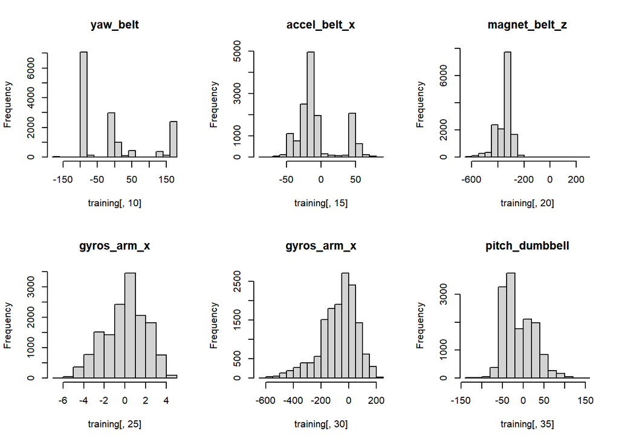

```r
par(mfrow=c(2,3))
hist(training[,10],main=names(training)[10])
hist(training[,15],main=names(training)[15])
hist(training[,20],main=names(training)[20])
hist(training[,25],main=names(training)[25])
hist(training[,30],main=names(training)[25])
hist(training[,35],main=names(training)[35])
```

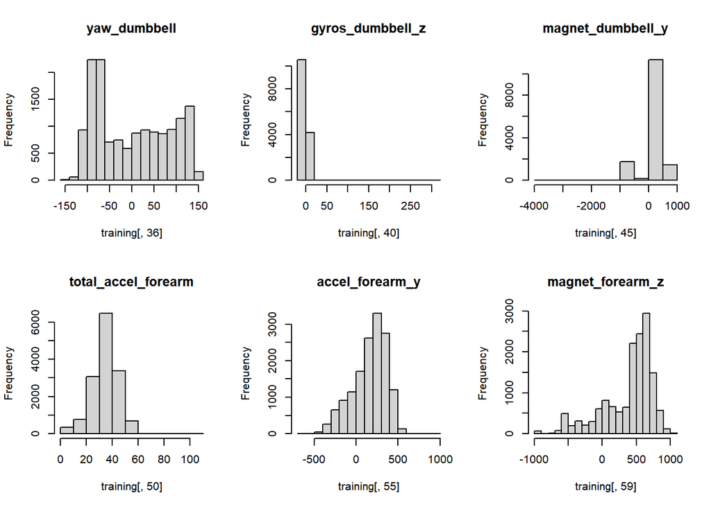

```r
par(mfrow=c(2,3))
hist(training[,36],main=names(training)[36])
hist(training[,40],main=names(training)[40])
hist(training[,45],main=names(training)[45])
hist(training[,50],main=names(training)[50])
hist(training[,55],main=names(training)[55])
hist(training[,59],main=names(training)[59])
```

## Fit the Model

We have selected a random forest classifier here since it generally has the highest accuracy, and we can run it as long as we’ve reduced the predictors (PCA) with a 90% threshold and set R up to run on parallel cores. We’ve also decided to use k-fold cross validation to try to balance the risks of overfitting and model bias. We’ve selected 10 as the highest number we can reasonably do without too long of run times. k-fold is appropriate here since we have plenty of data. We do all this using the caret package.

```r
cluster <- makeCluster(detectCores() - 1) # convention to leave 1 core for OS
registerDoParallel(cluster)

rfFit1 <- train(classe~.,method="rf",data=training,
               preProcess="pca", trControl = trainControl(preProcOptions = list(thresh = 0.9)
                                                          ,method = "repeatedcv", number = 10))

stopCluster(cluster)
registerDoSEQ()
```

Now that we have our model fit, we can look at the accuracy of it’s classifications (looking out for any systemic issues or bias in classifying). We will do this using the testing data set we set aside before.

```r
Pred1 <- predict(rfFit1,testing)
t1<- table(factor(Pred1, levels=c("A","B","C","D","E")),
      factor(testing$classe, levels=c("A","B","C","D","E")))
confusionMatrix(t1)$overall[1]
```

```
##  Accuracy
## 0.9861338
```

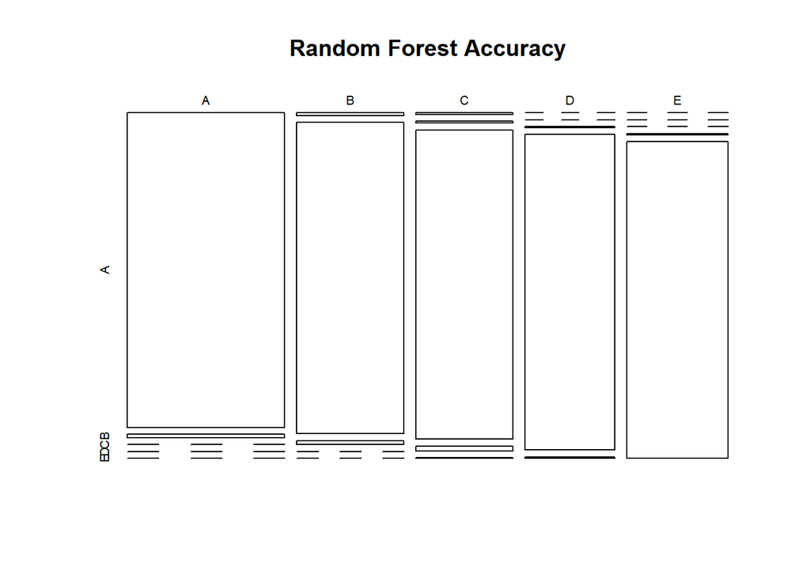

```r
par(mfrow=c(1,1))
plot(t1, col = confusionMatrix(t1)$byClass, main = paste("Random Forest Accuracy"))
```

Given this high accuracy, we’ll fit another type of model just for comparisons sake to see if the accuracy is better. Next we’ll try a boosted model, since it also uses bagging, like random forst, but it penalizes mistakes as it creates its trees.

```r
cluster <- makeCluster(detectCores() - 1) # convention to leave 1 core for OS
registerDoParallel(cluster)

rfFit2 <- train(classe~.,method="gbm",data=training,
               preProcess="pca", trControl = trainControl(preProcOptions = list(thresh = 0.9)
                                                          ,method = "repeatedcv", number = 10))
stopCluster(cluster)
registerDoSEQ()
```

Now we will evaluate the accuracy of the boosted model to see how it compares with random forest.

```r
Pred2 <- predict(rfFit2,testing)
t2<- table(factor(Pred2, levels=c("A","B","C","D","E")),
      factor(testing$classe, levels=c("A","B","C","D","E")))
confusionMatrix(t2)$overall[1]
```

```
## Accuracy
## 0.930261
```

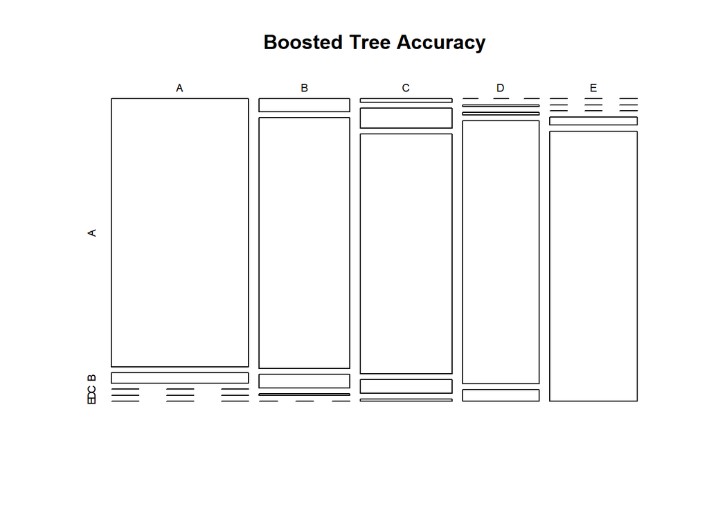

```r
par(mfrow=c(1,1))
plot(t2, col = confusionMatrix(t2)$byClass, main = paste("Boosted Tree Accuracy"))
```

The accuracy of the boosted model is still decent at 93.03%, but not as good as our random forest model. Hence we will use the random forest model as our final model and apply it to the original test set for our final predictions.

```r
PredFinal <- predict(rfFit1,testing_raw)
PredFinal
```

```
##  [1] B A A A A E D B A A B A B A E E A B B B
## Levels: A B C D E
```